# davis-allison-ADA-homework-2

Allison Davis

February 20, 2019

## MODULE 11

#### Probabilities and Distributions

### CHALLENGE 1:

*X = no. calls heard in each session;* *expected mean = lambda = 15*

#### 1a. Pr(X>8) in one session

```r
1- ppois(q=8, lambda = 15)
```

```
## [1] 0.9625535
```

#### 1b. Pr(X=0) in one session

```r
ppois(q=0, lambda = 15)
```

```
## [1] 3.059023e-07
```

```r
          #OR
dpois(x=0, lambda = 15)
```

```
## [1] 3.059023e-07
```

#### 1c. Pr(X=3) in one session

```r
dpois(x=3, lambda = 15)
```

```
## [1] 0.0001720701
```

#### 1d. Plot Poisson mass function with 0 ≤ x ≤ 30

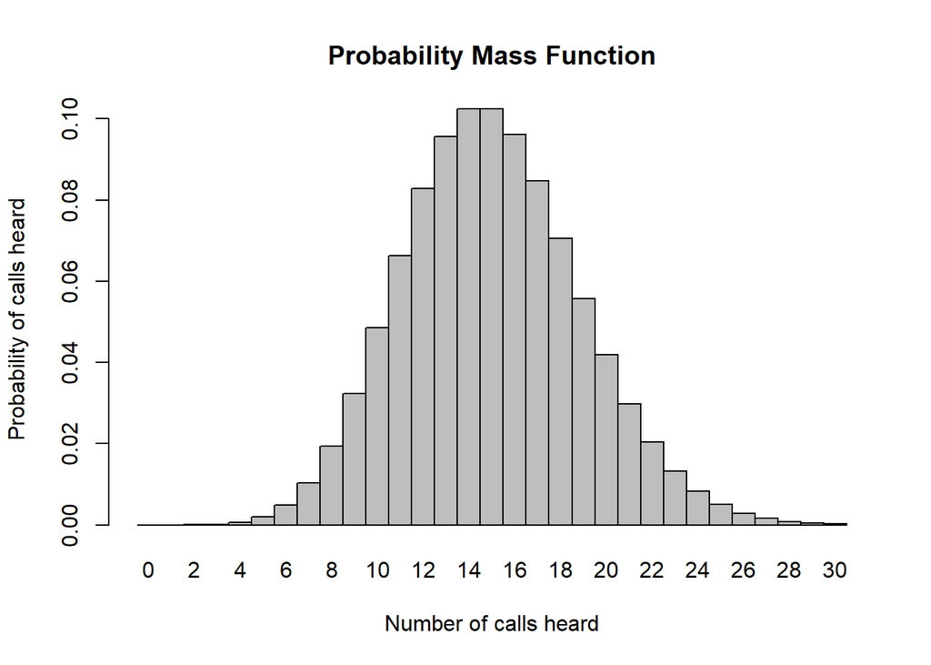

```r
titi <- dpois(x=0:30, lambda = 15)
barplot(titi, names.arg = 0:30, space = 0, xlab = "Number of calls heard", ylab = "Probability of calls heard", main = "Probability Mass Function")
```

#### 1e. Simulate 104 results from this distribution.

```r
two_yrs <- rpois(n=104, lambda = 15)
```

#### 1f. Plot simulation using hist() and xlim(), 0-30. Compare to 1d.

```r
par(1, 2)
```

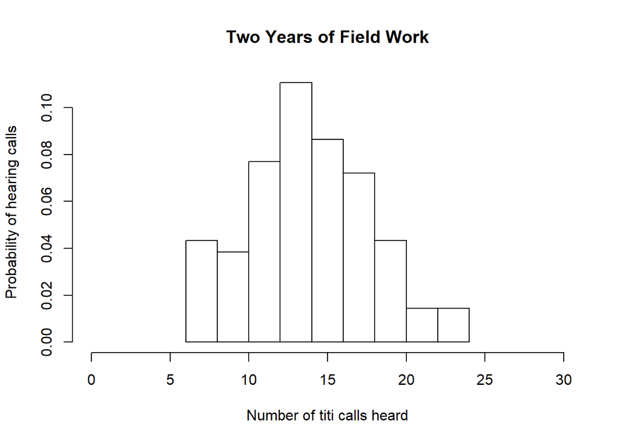

```r
hist(two_yrs, probability = TRUE, xlim = c(0,30), main = "Two Years of Field Work", xlab = "Number of titi calls heard", ylab = "Probability of hearing calls")
```

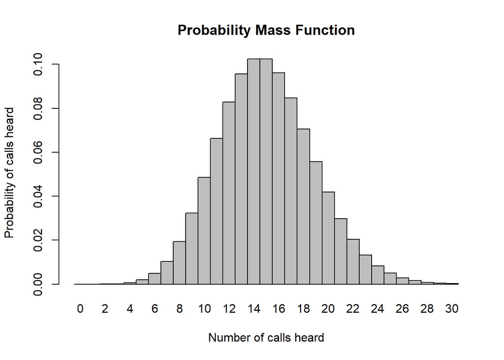

```r
titi <- dpois(x=0:30, lambda = 15)
barplot(titi, names.arg = 0:30, space = 0, xlab = "Number of calls heard", ylab = "Probability of calls heard", main = "Probability Mass Function")
```

### CHALLENGE 2:

*Zombie apocalypse survivors*

```r
library(curl)
z <- curl("https://raw.githubusercontent.com/difiore/ADA-2019/master/zombies.csv")

dZ <- read.csv(z, header = TRUE, sep = ",", stringsAsFactors = FALSE)

head(dZ)
```

```
##   id first_name last_name gender   height   weight zombies_killed
## 1  1      Sarah    Little Female 62.88951 132.0872              2
## 2  2       Mark    Duncan   Male 67.80277 146.3753              5
## 3  3    Brandon     Perez   Male 72.12908 152.9370              1
## 4  4      Roger   Coleman   Male 66.78484 129.7418              5
## 5  5      Tammy    Powell Female 64.71832 132.4265              4
## 6  6    Anthony     Green   Male 71.24326 152.5246              1
##   years_of_education                           major      age
## 1                  1                medicine/nursing 17.64275
## 2                  3 criminal justice administration 22.58951
## 3                  1                       education 21.91276
## 4                  6                  energy studies 18.19058
## 5                  3                       logistics 21.10399
## 6                  4                  energy studies 21.48355
```

#### 2a. **Population** mean and standard deviation for each quantitative random variable (height, weight, age, number of zombies killed, years of education).qrt

```r
(muH <- mean(dZ$height))
```

```
## [1] 67.6301
```

```r
(siH <- sqrt(sum((dZ$height - muH)^2)/1000))
```

```
## [1] 4.30797
```

```r
(muW <- mean(dZ$weight))
```

```
## [1] 143.9075
```

```r
(siW <- sqrt(sum((dZ$weight-muW)^2)/1000))
```

```
## [1] 18.39186
```

```r
(muA <- mean(dZ$age))
```

```
## [1] 20.04696
```

```r
(siA <- sqrt(sum((dZ$age-muA)^2)/1000))
```

```
## [1] 2.963583
```

```r
(muZK <- mean(dZ$zombies_killed))
```

```
## [1] 2.992
```

```r
(siZK <- sqrt(sum((dZ$zombies_killed-muZK)^2)/1000))
```

```
## [1] 1.747551
```

```r
(muEd <- mean(dZ$years_of_education))
```

```
## [1] 2.996
```

```r
(siEd <- sqrt(sum((dZ$years_of_education-muEd)^2)/1000))
```

```
## [1] 1.675704
```

#### 2b. Use {ggplot} to make boxplots of each variable by gender.

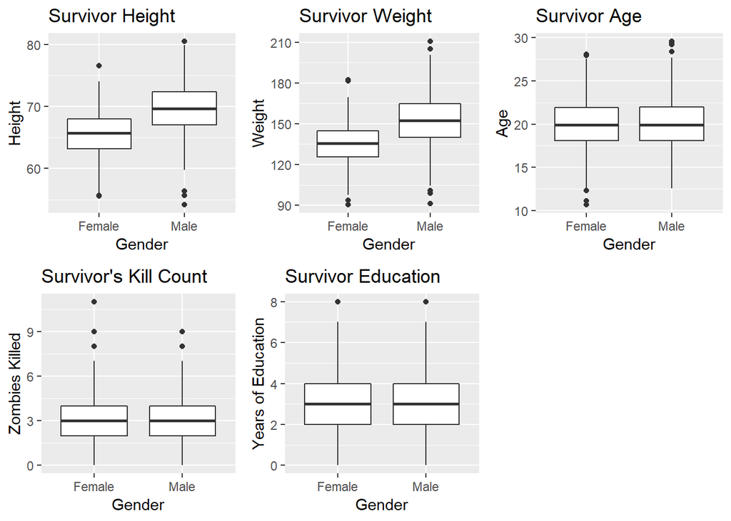

```r
library(ggplot2)
library(gridExtra)

H <- ggplot(dZ, aes(x= gender, y= height)) + geom_boxplot() + ggtitle("Survivor Height") + xlab("Gender") + ylab("Height")


W <- ggplot(dZ, aes(x= gender, y= weight)) + geom_boxplot() + ggtitle("Survivor Weight") + xlab("Gender") + ylab("Weight")


A <- ggplot(dZ, aes(x= gender, y= age)) + geom_boxplot() + ggtitle("Survivor Age") + xlab("Gender") + ylab("Age")


ZK <- ggplot(dZ, aes(x= gender, y= zombies_killed)) + geom_boxplot() + ggtitle("Survivor's Kill Count") + xlab("Gender") + ylab("Zombies Killed")


Ed <- ggplot(dZ, aes(x= gender, y= years_of_education)) + geom_boxplot() + ggtitle("Survivor Education") + xlab("Gender") + ylab("Years of Education")

grid.arrange(H, W, A, ZK, Ed, ncol=3, nrow=2)
```

#### 2c. Use {ggplot} to make scatterplots of height and weight in relation to age. Are they related? In what way?

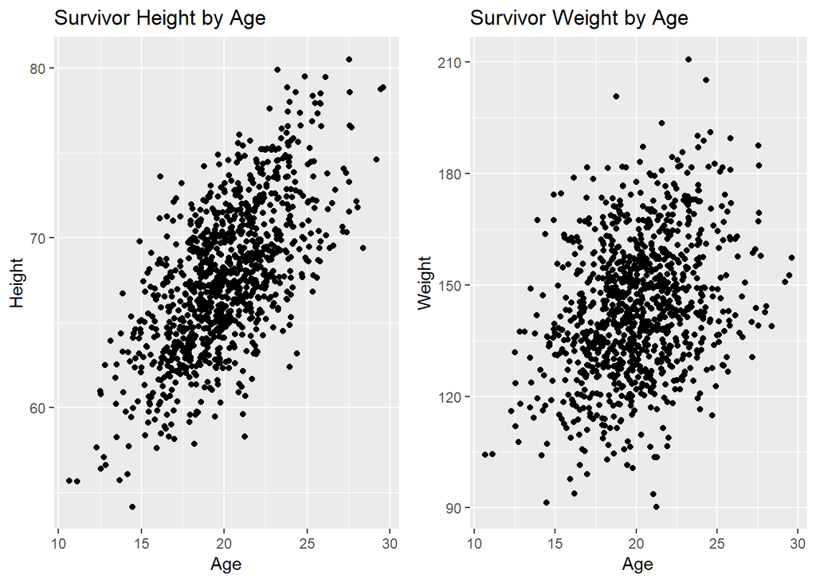

```r
H.A <- ggplot(dZ, aes(x=age, y=height)) + geom_point() + ggtitle("Survivor Height by Age") + xlab("Age") + ylab("Height")

W.A <- ggplot(dZ, aes(x=age, y=weight)) +geom_point() + ggtitle("Survivor Weight by Age") + xlab("Age") + ylab("Weight")

grid.arrange(H.A, W.A, ncol=2)
```

* Both scatterplots appear to have a positive linear correlation, therefore both height and weight are correlated to age. This makes sense since both height and weight increase with development over time. However, weight is not as strongly correlated since resource acquisition can depend on multiple variables, such as skill level or resource availability.

#### 2d. Determine which quantitative variables are drawn from normal distribution using histograms and Q-Q plots.

- for those that are not, determine what distribution they’re drawn from.

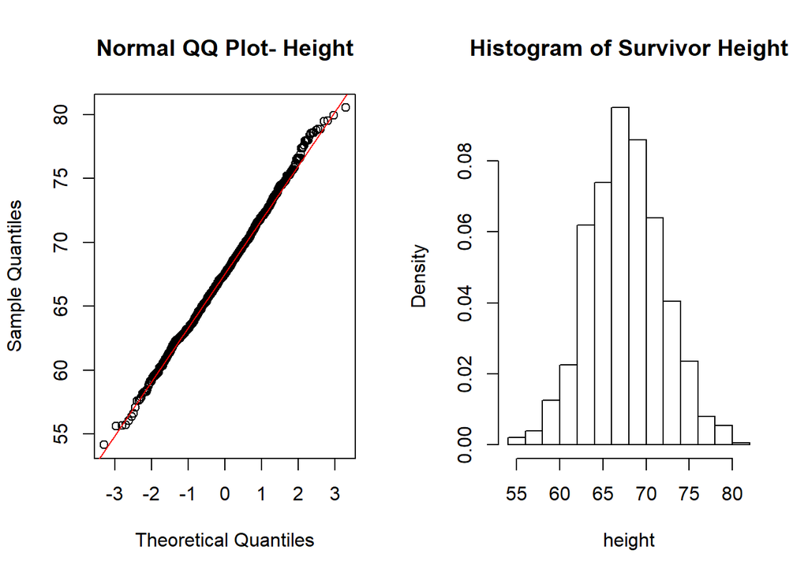

```r
attach(dZ)

par(mfrow= c(1, 2))

qqH <- {
  qqnorm(height, main = "Normal QQ Plot- Height")
  qqline(height, col="red") }

histH <- hist(height, main = "Histogram of Survivor Height", probability = TRUE)
```

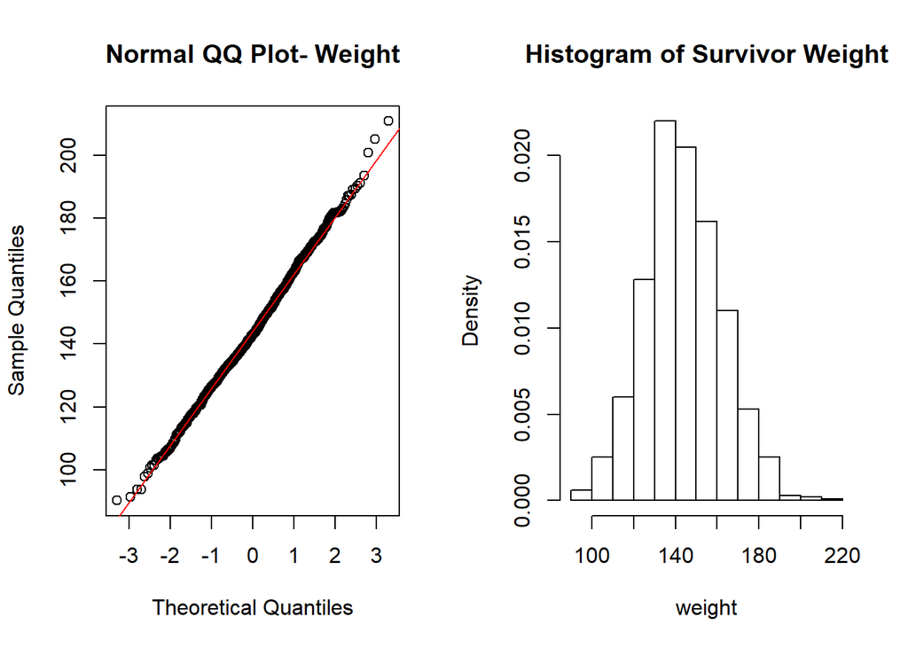

```r
qqW <- {
  qqnorm(weight, main = "Normal QQ Plot- Weight")
  qqline(weight, col="red") }

histW <- hist(weight, main = "Histogram of Survivor Weight", probability = TRUE)
```

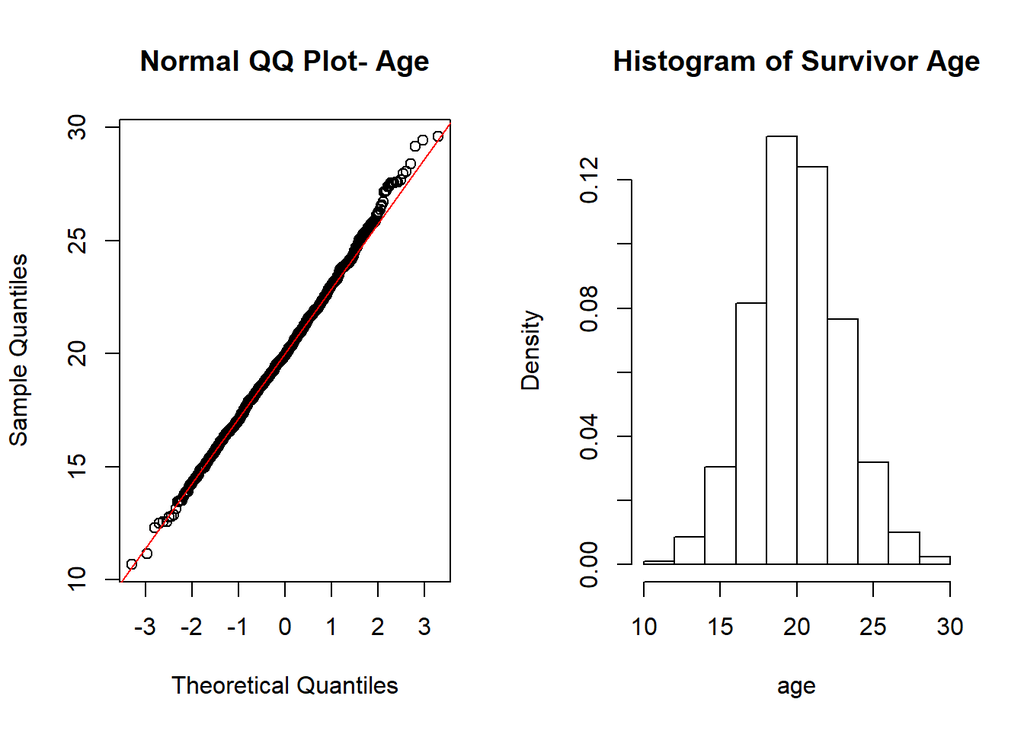

```r
qqA <- {
  qqnorm(age, main = "Normal QQ Plot- Age")
  qqline(age, col="red") }

histA <-  hist(age, main = "Histogram of Survivor Age", probability = TRUE)
```

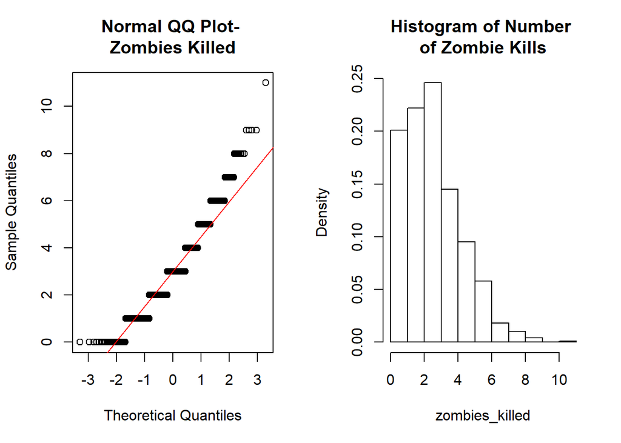

```r
qqZK <- {
  qqnorm(zombies_killed, main = "Normal QQ Plot- \nZombies Killed")
  qqline(zombies_killed, col="red") }

histZK <- hist(zombies_killed, main = "Histogram of Number \nof Zombie Kills", probability = TRUE)
```

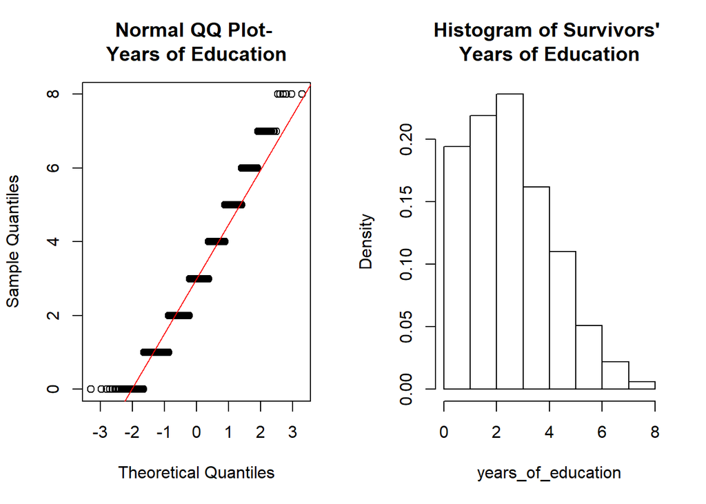

```r
qqEd <- {
  qqnorm(years_of_education, main = "Normal QQ Plot- \nYears of Education")
  qqline(years_of_education, col="red") }

histEd <- hist(years_of_education, main = "Histogram of Survivors' \nYears of Education", probability = TRUE)
```

#### 2e. Create a single subset of 30 survivors and calculate mean/sd for each variable. Estimate standard error for each variable and construct 95% confidence intervals for each mean.

```r
library(matrixStats)
set.seed(1)

alexandria <- dZ[sample(nrow(dZ), size=30, replace=FALSE),]

se <- function(x) {
  sd(x)/sqrt(length(x))
}

ci.H <- function(column, data=NULL) {
  column <- eval(substitute(column), data, parent.frame())
  qnorm(0.95/2, mean = mean(column), sd = sd(column))
}

ci.L <- function(column, data=NULL) {
  column <- eval(substitute(column), data, parent.frame())
  qnorm(0.05/2, mean = mean(column), sd = sd(column))
}

a.m <- colMeans(alexandria[,c(5:8,10)])
a.sd <- apply(alexandria[,c(5:8,10)],2,sd)
a.se <- apply(alexandria[,c(5:8,10)],2,se)
a.ci.H <- apply(alexandria[,c(5:8,10)],2,ci.H)
a.ci.L <- apply(alexandria[,c(5:8,10)],2,ci.L)

alex_Stats <- matrix(c(a.m, a.sd, a.se, a.ci.H, a.ci.L),5,5,byrow = FALSE)
colnames(alex_Stats) <- c("Mean", "Sd", "Sd.Er.", "CI-High", "CI-Low")
rownames(alex_Stats) <- c("Height", "Weight", "Age", "Zom.Killed", "Yrs Ed")
alex_Stats
```

[output not shown]

#### 2f. Repeat the previous step to get 100 total samples. Calculate mean/sd of sampling distributions for each variable and compare to mean/sd in *2e*. Describe distributions.

```r
library(dplyr)
k <- 99
n <- 30
safe_zone <- NULL
for (i in 1:k) {
  safe_zone[[i]] <- dZ[sample(nrow(dZ), size = n, replace = FALSE),]
}
head(safe_zone)
```

```
## [[1]]
##      id first_name last_name gender   height    weight zombies_killed
## 483 483      Steve    Howell   Male 54.14948  91.40652              4
## 599 599      Julia    Nguyen Female 64.33214 132.17689              5
## 493 493    Marilyn    Howell Female 58.27686  90.29148              1
## 186 186       Ruth      Webb Female 66.82291 119.43159              3
## 825 825     Martha     Banks Female 63.65938 134.61274              7
## 666 666      Donna     Green Female 68.13148 149.84863              1
## 790 790     Daniel Robertson   Male 70.66627 149.08637              3
## 108 108        Ann  Robinson Female 66.34735 140.14908              1
## 718 718     Carlos    Larson   Male 68.50593 139.81028              2
## 408 408       Paul   Kennedy   Male 71.09236 159.16052              2
## 813 813      Scott    Cooper   Male 70.65781 158.05911              4
## 640 640      Julia    Hunter Female 67.35270 147.30635              2
## 774 774    Stephen    Burton   Male 63.18440 135.80979              5
```

[output cut: 368 more lines]

```r
m.sZ_H <- NULL
for (i in 1:k) {
  m.sZ_H[i] <- mean(safe_zone[[i]]$height)
}


#sd.sZ <- NULL
#for (i in 1:k) {
  #sd.sZ[i] <- sd(safe_zone[[i]])
#}
    #wanted to find a way to do the analysis by columns, but could not figure out how to specify all interger columns and the [[i]] at the same time.
```